# Special topics: Discrete-stochastic simulations

**Learning Goals**

1. Understand demographic stochasticity
2. Be able to implement a model with demographic stochasticity in R, using 2 methods:
- discritization
- Gillespie’s Exact Method

**Packages you will need for this lesson**

1. `deSolve`
2. `ggplot2`

```r
library(deSolve)
library(ggplot2)
```

## ODEs vs. Discrete-stochastic simulations

Two of the hidden assumptions in using ODEs to describe the dynamics of ecological systems are:

1. The state variables are continuous variables, rather than integers. That is, we can have a small fraction of an individual. We often justify the use of ODEs by describing the state variables as **densities**, rather than numbers of individuals. e.g. we can have 0.47 infected individuals per square meter.
2. ODEs assume that the number of individuals in each of the classes is so large that the transitions between classes can be treated as **rates**. That is, we include a rate of transmission between the susceptible and infected class, and a rate of recovery from the infected class to the resistant class. This is ok if we are dealing with large populations, but if we want to model small populations, and in particular, if we want to look at the probability of disease-induced extinction of small populations, then individual births, deaths, trasmission events, and recovery of individuals.

***Demographic stochasticity** is the type of stochasticity resulting from discrete events happening to integer numbers of individuals at different points in time.

In order to implement demographic stochasticity, we first need to know how to flip a (potentially biased) coin, or roll a (potentially biased) n-sided die, in R, and do different things, depending on the outcome.

### Flippling a coin in R

In R, the useful command for this situation is: `runif(1)` which generates a single draw from a uniform distribution between 0 and 1.

If you want to flip an unbiased coin, such that the probability of heads is `p=0.5`, then you could say `u=runif(1)`, and if `u<0.5` then the outcome is “heads” and if `u>=0.5` then it’s “tails” .

If you want to flip a biased coin, such that the probability of heads is `p=0.55`, the criteria for a heads is `u<0.55`, and the criteria for a tails is `u>=0.55`.

If we are using a biased coin for which the probability of heads is `p=0.55`, and we want to set `x = 1` if the outcome is heads, and `x = 2` if the outcome is tails, then the R code is:

```r
p=0.55
u=runif(1)
if (u<p) {
x=1
} else {
    x=2
}
x
```

```
[1] 1
```

### Rolling the dice in R:

Now imagine you have a 3-sided die (hmm, that’s not actually possible. Maybe it’s actually a 3-sided spinner), with `p1 = 0.2`, `p2 = 0.3`, and `p3 = 1-p1-p2 = 0.5`.

Draw a uniformly distributed random number between 0 and 1: `u=runif(1)`.  
If `u < p1`, then you rolled a `1`.  
If `p1<= u < p1+p2`, then you rolled a `2`.  
If `u> (p1+p2)`, then you rolled a `3`.

R code:

```r
p1 = 0.2
p2 = 0.3
u=runif(1)
if (u<p1) {
         #insert whatever code you want executed upon rolling a 1#
     x = 1
} else if (u<(p1+p2) ) {
         #insert whatever code you want executed upon rolling a 2#
     x = 2
} else {
         #insert whatever code you want executed upon rolling a 3#
     x = 3
}
x
```

```
[1] 3
```

The reason we are assigning a name (`u`) to the draw from the uniform distribution, rather than just referring to it as `runif(1)` is that every time we use `runif(1)`, R will generate a new draw from the uniform distribution.

### Deterministic simulations of the continuous-time SIR model in R

Let’s go back to our continuous-time SIR model.

This model has three **state variables**:

- $S$: the density of susceptible (uninfected) individuals
- $I$: the density of infected individuals
- $R$: the density of recovered individuals, who are now resistant to further infection

And, it has 2 **parameters**:

- $\beta$: Transmission parameter (units = infecteds$^{-1}$time$^{-1}$)
- $\gamma$: Recovery rate (units = time$^{-1}$)

The system of first-order ODEs that describes the rate of change of the 3 state variables are:
$$\begin{align}
\frac{d S}{dt} &= -\beta I S \\
\frac{d I}{dt} &= \beta I S - \gamma I \\
\frac{d R}{dt} &= \gamma I
\end{align}$$
We know how to perform numerical simulations using `lsoda`. I’ll repeat that here:

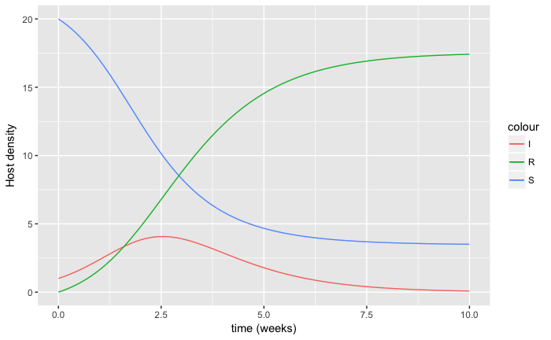

```r
# ALL OF THE CODE FOR THE DENSITY-DEPENDENT MODEL
SIR.model <- function (t, x, params) {
  S = x[1]
  I = x[2]
  R = x[3]
  beta = params[1]
  gamma = params[2]

  dSdt = -beta*S*I
  dIdt = beta*S*I - gamma*I
  dRdt = gamma*I

 return(list(c(dSdt,dIdt,dRdt)))
}
S0 = 20 # Initial number of susceptibles
I0 = 1 # Initial number of infecteds
R0 = 0 # Initial number of recovered
initial_values = c(S=S0,I=I0,R=R0)
beta = 0.1 # per host per week
gamma = 1 # per week
parameters = c(beta,gamma)
times = seq(0, 10, by=0.01)
results = lsoda(initial_values, times, SIR.model, parameters)
colnames(results) = c("time", "S", "I","R")
# Plotting in ggplot
ggplot(data=NULL, aes(x=results[, "time"], y=results[, "S"], color="S")) + geom_line() +
    geom_line(data=NULL, aes(x=results[, "time"], y=results[, "I"], color="I")) +
    geom_line(data=NULL, aes(x=results[, "time"], y=results[, "R"], color="R")) +
  xlab("time (weeks)") + ylab("Host density")
```

## Discrete Stochastic Simulations

**How do we generate one realization of a stochastic version of the model in which there are integer numbers of Susceptibles, Infecteds, and Resistant individuals, and discrete transmission and recovery events?**

We’ll explore 2 methods:

### Method 1: *Approximate* stochastic realization by dividing the system into discrete time steps:

One option would be to discretize time into small time steps $\Delta t$, and use the information that starting at a given number of susceptibles $S$, infecteds $I$, and recovereds $R$, within a small time interval, one of 3 things can happen:

- a **transmission event** can occur with probability $\beta S I \Delta t$.  
  If this occurs, then $S$ $\rightarrow$ $S-1$, and $I$ $\rightarrow$ $I+1$.
- a **recovery event** can occur with probability $\gamma I \Delta t$.  
  If this occurs, then $I$ $\rightarrow$ $I-1$ and $R$ $\rightarrow$ $R+1$
- **nothing happens** can occur with probability $1 -$ $\beta S I \Delta t$ $- \gamma I \Delta t$. If this occurs, then all of the state variable stay at their current values.

This method assumes that $\Delta t$ is sufficiently small that it is highly unlikely that two or more events will happen within the time interval.

#### The recipe for generating a single stochastic realization using Method 1 is:

1. Assign values to you parameters, $\beta$ and $\gamma$ , and set your time increment $\Delta t$.  
   ( Note: $1 -$ $\beta S I \Delta t$ $- \gamma I \Delta t$ has to be less than or equal to 1, so if $\beta$ or $\gamma$ is large, then you’ll have to use a smaller time step, $\Delta t$.)
2. Initialize $S$, $I$, and $R$ to some starting values. (If you want to save the values of the state variables at each time step, for example to plot them out at the end, then set up some type of R structure in which to hold the results (e.g. a vector or an array, or just `Svalues<-numeric(0)`).
3. Loop through time from a start time (e.g. `t=0`) to a stop time (e.g. Tend = 10) in increments of $\Delta t$ (perhaps using a `for` loop).  
   In each iteration of the loop do the following:
1. calculate the probability of a **transmission event**, $\beta S I \Delta t$.
2. calculate the probability of a **recovery event**, $\gamma I \Delta t$.
3. calculate the probability of **nothing happening**, $1 -$ $\beta S I \Delta t$ $- \gamma I \Delta t$.
4. roll a 3-sided die based on these probabilities, and update the state variables depending on the outcome.
4. Plot your results through time.

### Exercise 1: Use Method 1 to generate a stochastic realization of the SIR model

> 1. In R, implement the recipe for generating a single stochastic realization using Method 1, and plot one realization of $S$, $I$, and $R$ through time.

```r
#HIDE ME IF YOU DON'T WANT TO SEE THE ANSWER
# FOR METHOD 1: discrete stochastic simulation of SIR model
Tend = 10
dt = 0.01
time = seq(0,Tend,dt)
S0 = 20 # Initial number of susceptibles
I0 = 2 # Initial number of infecteds
R0 = 0 # Initial number of recovered
beta = 0.1 # per host per week
gamma = 1 # per week
S=numeric(length(time))
I=numeric(length(time))
R=numeric(length(time))
S[1] = S0
I[1] = I0
R[1] = R0
for (i in 1:(length(time)-1)) {
    p1 <- beta*S[i]*I[i]*dt  # probability of a transmission event
    p2 <- gamma*I[i]*dt    # probability of a recovery event
    u = runif(1)
        if ( u<p1 ) { # a transmission event occurs
         S[i+1] = S[i] - 1
         I[i+1] = I[i] + 1
         R[i+1] = R[i]
        } else if ( u<(p1+p2) ) { # a recovery event occurs
         S[i+1] = S[i]
         I[i+1] = I[i] - 1
         R[i+1] = R[i] + 1
        } else {  # no events happen in dt
         S[i+1] = S[i]
         I[i+1] = I[i]
         R[i+1] = R[i]
    }
}
plot(time,S,type="l", col="red", ylim = c(0,S0+I0+R0), xlab = )
lines(time,I,type="l", col = "green")
```

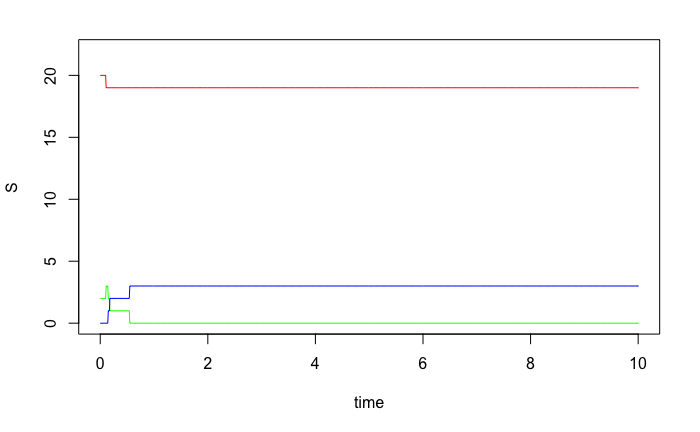

```r
lines(time,R,type="l", col = "blue")
```

> 2. In R, set up a loop to run a large number of stochastic realizations of this model, only saving the final state of the system for each run (e.g. the value of $R$ at time = 100). Plot a histogram of these states. Do they look like any familiar distribution?

> For example, if your list of final values of $R$ for your multiple runs is stored in `Rsave`, you can plot a histogram of the frequencies using the command:

> `hist(Rsave, freq = FALSE, col = "grey")`

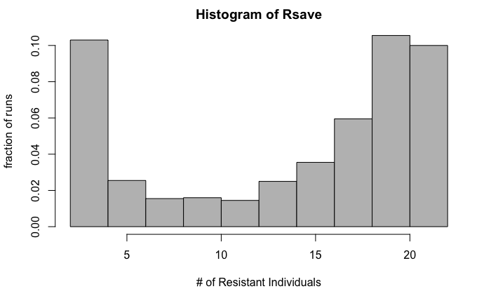

```r
#HIDE ME IF YOU DON'T WANT TO SEE THE ANSWER
# FOR METHOD 1: discrete stochastic simulation of SIR model
Nruns = 1000
Tend = 100
dt = 0.01
time = seq(0,Tend,dt)
S0 = 20 # Initial number of susceptibles
I0 = 2 # Initial number of infecteds
R0 = 0 # Initial number of recovered
beta = 0.1 # per host per week
gamma = 1 # per week
Ssave=numeric(Nruns)
Isave=numeric(Nruns)
Rsave=numeric(Nruns)
for (run in 1:Nruns) {
  #start each run at the initial conditions
S = S0
I = I0
R = R0
  for (i in 1:(length(time)-1)) {
      p1 <- beta*S*I*dt  # probability of a transmission event
      p2 <- gamma*I*dt    # probability of a recovery event
      u = runif(1)
    if ( u<p1 ) { # a transmission event occurs
         S = S - 1
         I = I + 1
         R = R
     } else if ( u<(p1+p2) ) { # a recovery event occurs
         S = S
         I = I - 1
         R = R + 1
     } else {  # no events happen in dt
         S = S
         I = I
         R = R
     }
      } # end for (i in 1:(length(time)-1))
# at the end of each run, save only the final value
Ssave[run]=S
Isave[run]=I
Rsave[run]=R
} # end for (run in 1:Nruns)
hist(Rsave, freq = FALSE, col = "grey", xlab = "# of Resistant Individuals", ylab = "fraction of runs")
```

### Method 2: Exact stochastic realization using Gillespie’s algorithm:

Although Method 1 is easy to understand and implement, it is just an approximation and assumes that $\Delta t$ is small enough that the probability that two events (births and deaths, or in our model, multiple transmission and/or recovery events) occur within $\Delta t$ is negligible. The Gillespie algorithm (Gillespie 1977) is an exact alternative that instead treats time as continuous and uses two random numbers to determine:  
(i) the time to the next event, and  
(ii) which event occurs.

The general set-up for this Stochastic Simulation Algorithm (SSA) was first formulated for chemical systems, but it applies to ecological systems equally well (and has been used in a number of ecological models). The set-up is as follows (from: Li and Petzold, Bioinformatics 2005):

Consider a spatially homogeneous chemically reacting system with a fixed volume and at a constant temperature.

The system involves N molecular species: $\{S_1, …, S_N\}$, represented by the dynamical state vector $X(t) = (X_1(t), …, X_N(t)), where X_i(t) $is the population of species $S_i$ in the system at time $t$.

In the system being modeled, there are $K$ chemical reactions, $\{R_1, … R_K\}$. Each reaction $R_j$ is characterized by:

a **propensity** $a_j$, where $a_j(x)\Delta t$ is the probability, given the state of the system at time $t$, that one $R_j$ reaction will occur in the next infinitesimal time interval $[t,t+\Delta t)$, and

a **state change vector** $v_j = \{v_{1j}, …, v_{Nj}\}$, in which $v_{ij}$ is the change in the number of species $S_i$ due to one $R_j$ reaction.

For any given current state of the system, $X(t) = x_t$, the time $\tau$ to the next reaction is exponentially distributed with mean = $1/a_{tot}(x_t)$, where $a_{tot}(x_t)$ is the sum of the propensities of all of the possible reactions: $a_{tot}(x_t) = \Sigma(a_j(x_t))$.

If $u_1$ is a uniformly distributed random number in the interval $[0,1]$, then at any point in time, a value of $\tau$ (time to the next reaction) can be generated by:

$$\begin{align}
\tau = \frac{1}{ a_{tot}(x_t) } \ln ( \frac{1}{u_1} )
\end{align}$$

For each reaction $(j = 1,…K)$, the probability that the next reaction is of type j is:
$$\begin{align}
P(j | x,t) = \frac{a_{j}(x_t)}{ a_{tot}(x_t) }
\end{align}$$

If $u_2$ is a second uniformly distributed random number in the interval $[0,1]$, then the type of the next reaction can be determined by rolling a K-sided die, with the probability of the die landing on each of the $K$ sides being $P(j|x,t)$ for $j = 1,…K$.

#### recipe for generating a single stochastic realization using The Gillespie Algorithm is:

1. Assign values to you parameters, $\beta$ and $\gamma$.
2. Initialize the state of the system to some starting value.  
   (Again, if you want R to save the values of the state variables at each time step, for example to plot them out at the end, then set up some type of R structure in which to hold the results (e.g. a vector or an array, or just Svalues<-numeric(0))).
3. Initialize time to t = 0  
   (If you want to plot your results through time, you’ll also want to save the value of time at each time step, e.g. tvalues<-numeric(0))
4. Loop through time, in this case because time is going to jump forward in uneven increments, perhaps use a while loop (e.g. `while (t<Tend)`, where $Tend$ is whatever final time you choose for your simulations). In each iteration of the loop do the following:
1. Calculate the current values of the propensity functions based on the current state of the system.  
   For this example, we have 2 possible reactions (we are ignoring the reactions that don’t affect the concentration of M):
- R1: pathogen transmission: $S$ $\rightarrow$ $S-1$, $I$ $\rightarrow$ $I+1$
- R2: infected recovery: $I$ $\rightarrow$ $I-1$, $R$ $\rightarrow$ $R+1$

The propensities of these two reactions are:  
$a1 = \beta S I$  
$a2 = \gamma I$  
and, $atot = a1+a2$

### Exercise 2: Use Method 2 (Gillespie Algorithm) to generate a stochastic realization of the SIR model

#### Exercise 2b:

> 1. In R, implement the recipe for generating a single stochastic realization using Method 2, and plot one realization of $S$, $I$, and $R$ through time.

```r
#HIDE ME IF YOU DON'T WANT TO SEE THE ANSWER

# Method 2: Gillespie Algorithm

Tend = 10
t = 0

S = 20 # Initial number of susceptibles
I = 2 # Initial number of infecteds
R = 0 # Initial number of recovered

beta = 0.1 # per host per week
gamma = 1 # per week

Ssave = numeric(0)
Isave = numeric(0)
Rsave = numeric(0)
Tsave = numeric(0)

Ssave[1] = S
Isave[1] = I
Rsave[1] = R
Tsave[1] = 0

i=1
while ((t<Tend) & (I>0)) {
    i=i+1
    a1 = beta*S*I
    a2 = gamma*I
    atot = a1+a2

    u1 = runif(1)
    u2 = runif(1)

    tau<-log(1/u1)/atot
    t<-t+tau

  if ( u2<(a1/atot) ) {
          S = S - 1
          I = I + 1
  }
  else {
          I = I - 1
          R = R + 1
  }
Ssave[i]<-S
Isave[i]<-I
Rsave[i]<-R
Tsave[i]<-t
}

plot(Tsave,Ssave,type="l", col = "red", xlab = "time (weeks)", ylab = "hosts", xlim = c(0,Tend), ylim = c(0,max(Ssave)))
lines(Tsave,Isave,type="l", col="green")
lines(Tsave,Rsave,type="l", col="blue")
```

[output not shown]

#### Exercise 2b:

> 2. In R, set up a loop to run a large number of stochastic realizations of this model, only saving the final state of the system for each run (e.g. the value of $R$ at time = 100). Plot a histogram of these states. Do they look like any familiar distribution?

> For example, if your list of final values of $R$ for your multiple runs is stored in `Rsave`, you can plot a histogram of the frequencies using the command:

> `hist(Rsave, freq = FALSE, col = "grey")`

```r
#HIDE ME IF YOU DON'T WANT TO SEE THE ANSWER

# Method 2: Gillespie Algorithm

Nruns = 100
Tend = 100

beta = 0.1 # per host per week
gamma = 1 # per week

Ssave = numeric(Nruns)
Isave = numeric(Nruns)
Rsave = numeric(Nruns)
Tsave = numeric(Nruns)

for (run in 1:Nruns) {

  t = 0

  S = 20 # Initial number of susceptibles
  I = 2 # Initial number of infecteds
  R = 0 # Initial number of recovered

  while ((t<Tend) & (I>0)) {
    a1 = beta*S*I
      a2 = gamma*I
      atot = a1+a2

      u1 = runif(1)
      u2 = runif(1)

      tau<-log(1/u1)/atot
      t<-t+tau

    if ( u2<(a1/atot) ) {
          S = S - 1
          I = I + 1
    }
    else {
          I = I - 1
          R = R + 1
    }
} # end while()
Ssave[run]<-S
Isave[run]<-I
Rsave[run]<-R
Tsave[run]<-t
} #end for (run in 1:Nruns)

hist(Rsave, freq = FALSE, col = "grey", xlab = "# of Resistant Individuals", ylab = "fraction of runs")
```

[output not shown]